# Coursera Practical Machine Learning Assignment

Goloshchapova Irina

18.08.2015

# Syllabus

In this project, our goal will be to use data from accelerometers on the belt, forearm, arm, and dumbell of 6 participants. They were asked to perform barbell lifts correctly and incorrectly in 5 different ways. Detailed information is available from the [website](http://groupware.les.inf.puc-rio.br/har). Training dataset was collected [here](https://d396qusza40orc.cloudfront.net/predmachlearn/pml-training.csv) and testing data set - [here](https://d396qusza40orc.cloudfront.net/predmachlearn/pml-testing.csv).  
After the data preprocessing and exploratory analysis steps we evaluate several classification models on the training set, compare them on the validation set and implement the best algoritm on the testing set for submitting the result to Coursera website for grading.

# Data Preprocessing

**Step 1: Loading raw data and required packages.**

`summary(trainRaw$classe)`

```
##    A    B    C    D    E
## 5580 3797 3422 3216 3607
```

As a result, we have 19622 rows and 160 columns in training dataset and 20 rows and 160 columns in test dataset. This is raw data and it should be sufficiently preprocessed before modeling part.

Full code of this part is shown in Appendix.Loading data.

**Step 2: Covariate set cleaning**

There are several approaches for reducing the number of predictors.

- *Remove variables with too many NA values.* For the purpose of this analysis we take only predictors that have no NAs.  
  As a result, we remove 100 predictors.
- *Remove unrelevant variables.* We take as predictors only belt, arm, dumbbell, and forearm variables and remove ones with unrelevant names.  
  As a result, we remove 7 predictors.
- *Remove variables with near zero variance and near zero fraction of unique values.* For this task `nearZeroVar()` function from caret package could be very helpful.  
  As a result, we remove 0 predictors.
- *Remove highly correlated variables.* We take as predictors only variables with correlation lower than 85%.  
  As a result, we remove 8 predictors.

You could see the code for the evaluation part of this section in Appendix.Covariates preprocessing.

**Correlogramm of covariates**

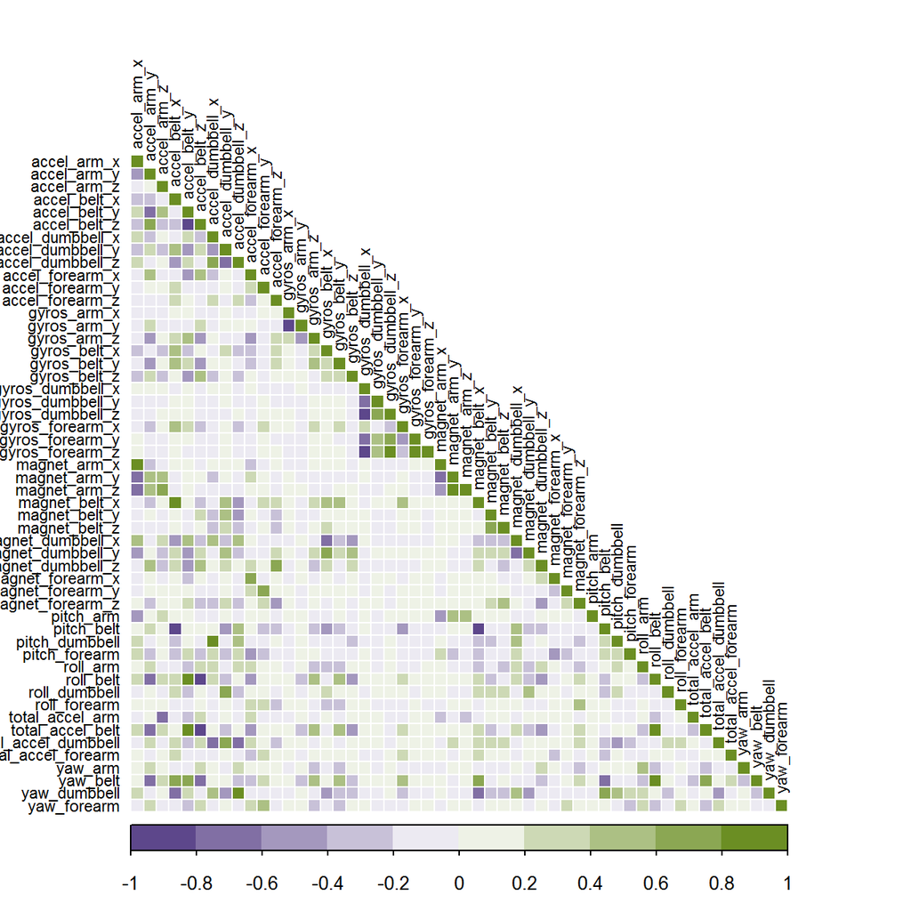

The code for the plot is placed in Appendix.Corrplot.

Finally, we got a dataset of potential predictors with outcom variable `classe` and 44 covariates. And total 19622 observations for each variable.

**Step 3: Splitting final dataset into train and validation sets**

```r
set.seed(2301)
inTrain <- createDataPartition(trainItog$classe, p=0.7, list=FALSE)
train <- trainItog[inTrain,]
valid <- trainItog[-inTrain,]
```

So we got 13737 rows and 45 columns in training dataset and 5885 rows and 45 columns in validation dataset.

# Model evaluation

Now through evaluating models on the training set we are going to implement several machine learning algorithms that are in general effective. Models evaluation will be controlled by the 5-fold cross-validation procedure. Then we’ll compare models by general “goodness of fit” on the validation set and choose the best model for the testing set prediction.

**Step 1: Evaluating models on the training set with 5-fold cross-validation**

Here we implement:

1. C 5.0 (`C5.0`)
2. Boosted trees (`gbm`)
3. Random forests (`rf`)
4. Bagged trees (`treebag`)
5. Neural networks (`nnet`)
6. Support Vector Machines (`svmRadial`)

The appropriate measure of the total “goodness of fit” for categorical variable prediction is the *accuracy measure*. It equals total right predictions divided by the total observations number.

You could find the whole code for this part in Appendix.Evaluating models.

As a result we have the following tables.

|  | Accuracy | Sensitivity | Specificity | Pos.Pred.Value | Neg.Pred.Value |
| --- | --- | --- | --- | --- | --- |
| C5.0 | 1.00 | 1.00 | 1.00 | 1.00 | 1.00 |
| gbm | 0.97 | 0.99 | 0.95 | 0.94 | 0.97 |
| rf | 1.00 | 1.00 | 1.00 | 1.00 | 1.00 |
| treebag | 1.00 | 1.00 | 1.00 | 1.00 | 1.00 |
| nnet | 0.39 | 0.42 | 0.44 | NA | 0.24 |
| svmRadial | 0.81 | 0.90 | 0.82 | 0.74 | 0.72 |

**Step 2: comparing models by general “goodness of fit” on the validation set**

**Table 2. Model evaluation results: validation set.**

|  | Accuracy | Sensitivity | Specificity | Pos.Pred.Value | Neg.Pred.Value |
| --- | --- | --- | --- | --- | --- |
| C5.0 | 0.99 | 1.00 | 0.99 | 0.99 | 0.99 |
| gbm | 0.96 | 0.97 | 0.95 | 0.91 | 0.96 |
| rf | 0.99 | 1.00 | 0.99 | 0.98 | 0.99 |
| treebag | 0.98 | 0.99 | 0.98 | 0.97 | 0.97 |
| nnet | 0.38 | 0.40 | 0.46 | NA | 0.25 |
| svmRadial | 0.80 | 0.90 | 0.82 | 0.71 | 0.69 |

According to the results, the best algorithm for the prediction of the outcome variable (`classe`) is *also* C5.0 classification algorithm. It shows almost perfect prediction for the validation set also. This makes the overfitting possibility sufficiently lower.

So, the final best model we choose for the testing set outcome prediction is C5.0.

For reference, the C5.0 method is based on C4.5, which in turn according to [Wu et al.(2007)](http://www.cs.uvm.edu/~icdm/algorithms/10Algorithms-08.pdf) is one of the most popular (top 10) machine learning algorithms in data mining.  
You could read good detail description of this algorithm [here](http://rayli.net/blog/data/top-10-data-mining-algorithms-in-plain-english/#1_C45).

# Final model presentation

Code for this part could be found in Appendix.Presenting final model.

**Table 3. Confusion Matrix for the training set.**

| Prediction/Reference | A | B | C | D | E |
| --- | --- | --- | --- | --- | --- |
| A | 3906 | 0 | 0 | 0 | 0 |
| B | 0 | 2658 | 0 | 0 | 0 |
| C | 0 | 0 | 2396 | 0 | 0 |
| D | 0 | 0 | 0 | 2252 | 0 |
| E | 0 | 0 | 0 | 0 | 2525 |

**Table 4. Confusion Matrix for the validation set.**

| Prediction/Reference | A | B | C | D | E |
| --- | --- | --- | --- | --- | --- |
| A | 1670 | 1 | 3 | 0 | 0 |
| B | 6 | 1125 | 7 | 0 | 1 |
| C | 0 | 10 | 1007 | 8 | 1 |
| D | 0 | 0 | 4 | 959 | 1 |
| E | 0 | 0 | 0 | 1 | 1081 |

**Table 5. Variable Importance.**

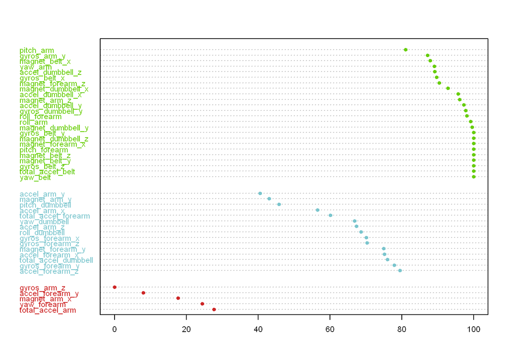

**Tuning details**

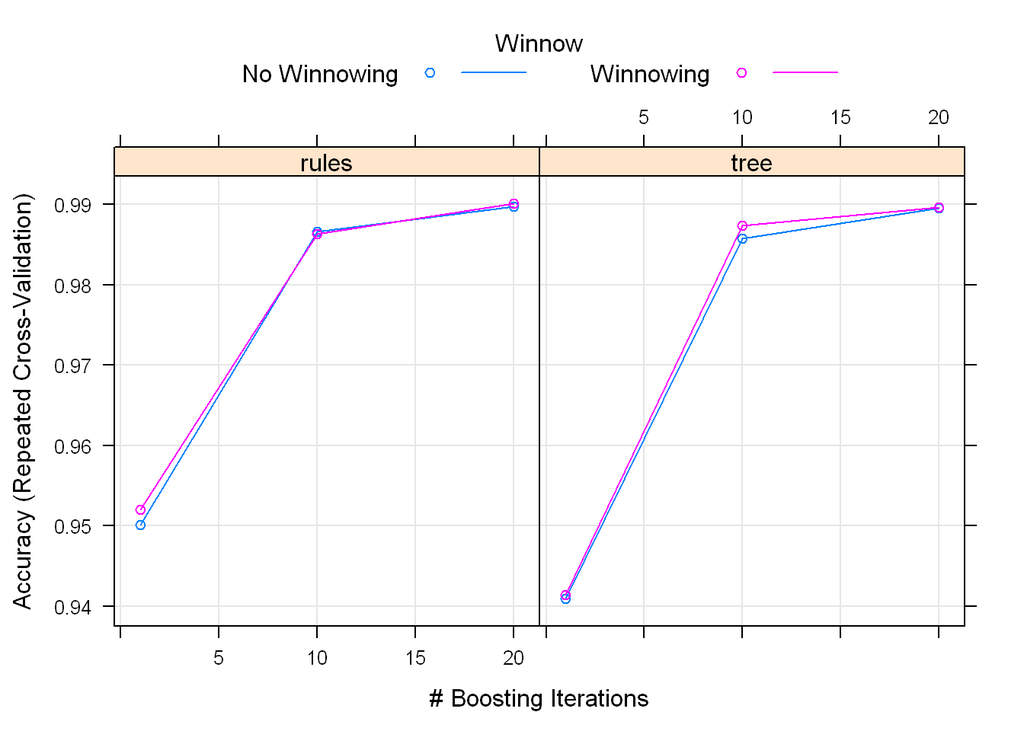

# Submission to Coursera

Now we could predict `classe` values and submit the result to Coursera.

```r
# Prediction
answers <- predict(C5.0.m, testRaw)
answers <- as.character(answers)

# Preparation for submission
pml_write_files = function(x){
  n = length(x)
  path <- "C:/PracticalML/Answers"
  for(i in 1:n){
    filename = paste0("problem_id_",i,".txt")
    write.table(x[i],file=file.path(path, filename),quote=FALSE,row.names=FALSE,col.names=FALSE)
  }
}
pml_write_files(answers)
```

# Appendix

## Appendix.Loading data

```r
library(ggplot2)
library(caret)
library(randomForest)
library(e1071)
library(corrplot)


options(digits = 2)
setwd("C:/PracticalML")

download.file("http://d396qusza40orc.cloudfront.net/predmachlearn/pml-training.csv", destfile = "Train.csv")
download.file("http://d396qusza40orc.cloudfront.net/predmachlearn/pml-testing.csv", destfile = "Test.csv")

trainRaw = read.csv("Train.csv", na.strings=c("", "NA", "NULL"))
testRaw = read.csv("Test.csv", na.strings=c("", "NA", "NULL"))

trainRaw$classe <- as.factor(trainRaw$classe)

summary(trainRaw$classe)
```

## Appendix. Covariates preprocessing

```r
# Removing columns with NAs
trainTrf <- trainRaw[ , colSums(is.na(trainRaw)) == 0]
delta1 <- dim(trainRaw)[2] - dim(trainTrf)[2]

# Removing unrelevant variables
relevantVar <- grepl("belt|[^(fore)]arm|dumbbell|forearm|classe", names(trainTrf))
trainRel <- trainTrf[, relevantVar]
delta2 <- dim(trainTrf)[2] - dim(trainRel)[2]

# Removing nzv variables
nzv= nearZeroVar(trainRel[sapply(trainRel, is.numeric)], saveMetrics = TRUE)
trainNnzv = trainRel[, nzv[, 'nzv'] == FALSE]
delta3 <- dim(trainRel)[2] - dim(trainNnzv)[2]

# Remove highly correlated variables
corrM <- cor(trainNnzv[sapply(trainNnzv, is.numeric)])
highCorr <- findCorrelation(corrM, cutoff = .85, verbose = FALSE)
trainItog <- trainNnzv[, -highCorr]
delta4 <- dim(trainNnzv)[2] - dim(trainItog)[2]
```

## Appendix.Corrplot

```r
par(oma = c(0,0,2,0))
colour <- colorRampPalette(c("mediumpurple4", "white", "olivedrab"))
corrplot(corrM, col = colour(10), order = "alphabet",
         method = "color", type = "lower",
         tl.cex = 0.7, tl.col = "black", main = "Correlation matrix of covariates")
```

## Appendix.Evaluating models

```r
# set seed
set.seed(2301)

# Setting clusters
cl <- makeCluster(detectCores() - 1)
registerDoParallel(cl)

# Setting control parameters
ctrl <- trainControl(method = "repeatedcv",
                     number = 5,
                     classProbs=TRUE,
                     savePredictions=TRUE,
                     allowParallel=TRUE)

# (1) C5.0
C5.0.m <- train(train$classe ~ ., method = "C5.0", verbose = FALSE,
               data = train, trControl = ctrl) # evaluating C5.0
cm5.0 <- confusionMatrix(valid$classe,
                      predict(C5.0.m, valid)) # conf matrix for valid set
quality <- c(cm5.0$overall[1], cm5.0$byClass[1:4])

cm5.0tr <- confusionMatrix(train$classe,
                      predict(C5.0.m, train)) # conf matrix for train set
quality.train <- c(cm5.0tr$overall[1], cm5.0tr$byClass[1:4])

# (2) gbm
gbm.m <- train(train$classe ~ ., method = "gbm", verbose = FALSE,
               data = train, trControl = ctrl)
cm.gbm <- confusionMatrix(valid$classe,
                      predict(gbm.m, valid))
quality.new <- c(cm.gbm$overall[1], cm.gbm$byClass[1:4])
quality <- rbind(quality, quality.new)

cm.gbmtr <- confusionMatrix(train$classe,
                      predict(gbm.m, train))
quality.train.new <- c(cm.gbmtr$overall[1], cm.gbmtr$byClass[1:4])
quality.train <- rbind(quality.train, quality.train.new)

# (3) rf
rf.m <- train(train$classe ~ ., method = "rf", verbose = FALSE,
               data = train, trControl = ctrl)
cm.rf <- confusionMatrix(valid$classe,
                      predict(rf.m, valid))
quality.new <- c(cm.rf$overall[1], cm.rf$byClass[1:4])
quality <- rbind(quality, quality.new)

cm.rftr <- confusionMatrix(train$classe,
                      predict(rf.m, train))
quality.train.new <- c(cm.rftr$overall[1], cm.rftr$byClass[1:4])
quality.train <- rbind(quality.train, quality.train.new)
# (4) treebag
treebag.m <- train(train$classe ~ ., method = "treebag",
                   verbose = FALSE, data = train, trControl = ctrl)
cm.treebag <- confusionMatrix(valid$classe,
                      predict(treebag.m, valid))
quality.new <- c(cm.treebag$overall[1], cm.treebag$byClass[1:4])
quality <- rbind(quality, quality.new)

cm.treebagtr <- confusionMatrix(train$classe,
                      predict(treebag.m, train))
quality.train.new <- c(cm.treebagtr$overall[1], cm.treebagtr$byClass[1:4])
quality.train <- rbind(quality.train, quality.train.new)

# (5) nnet
nnet.m <- train(train$classe ~ ., method = "nnet",
                   verbose = FALSE, data = train, trControl = ctrl)
cm.nnet <- confusionMatrix(valid$classe,
                      predict(nnet.m, valid))
quality.new <- c(cm.nnet$overall[1], cm.nnet$byClass[1:4])
quality <- rbind(quality, quality.new)

cm.nnettr <- confusionMatrix(train$classe,
                      predict(nnet.m, train))
quality.train.new <- c(cm.nnettr$overall[1], cm.nnettr$byClass[1:4])
quality.train <- rbind(quality.train, quality.train.new)

# (6) svmRadial
svmRadial.m <- train(train$classe ~ ., method = "svmRadial",
                   verbose = FALSE, data = train, trControl = ctrl)
cm.svmRadial <- confusionMatrix(valid$classe,
                      predict(svmRadial.m, valid))
quality.new <- c(cm.svmRadial$overall[1], cm.svmRadial$byClass[1:4])
quality <- rbind(quality, quality.new)

cm.svmRadialtr <- confusionMatrix(train$classe,
                      predict(svmRadial.m, train))
quality.train.new <- c(cm.svmRadialtr$overall[1], cm.svmRadialtr$byClass[1:4])
quality.train <- rbind(quality.train, quality.train.new)

# Stop clusters
stopCluster(cl)

# Naming datasets
methods.m <- c("C5.0", "gbm", "rf", "treebag",
               "nnet", "svmRadial")
quality <- as.data.frame(quality)
quality.train <- as.data.frame(quality.train)

row.names(quality) <- methods.m
row.names(quality.train) <- methods.m
```

```r
library(printr)
options(digits = 2)
names.col <- c("Accuracy", "Sensitivity", "Specificity",
               "Pos.Pred.Value", "Neg.Pred.Value")
names(quality.train) <- names.col
quality.train
```

```r
options(digits = 2)
names(quality) <- names.col
quality
```

# Appendix. Presenting final model

**Table 3. Confusion Matrix for the training set.**

```r
cm5.0tr$table
```

**Table 4. Confusion Matrix for the validation set.**

```r
cm5.0$table
```

**Table 5. Variable Importance.**

```r
a <- varImp(C5.0.m)

groups <- 1
groups <- ifelse(a$importance[, 1] > 80,
                 1, ifelse(a$importance[, 1] > 40, 2, 3))
colours <- 1
colours <- ifelse(a$importance[, 1] > 80,
                  "chartreuse3", ifelse(a$importance[, 1] > 40,
                                        "cadetblue3", "firebrick3"))

dotchart(a$importance[, 1], labels = row.names(a$importance),
         groups = groups,
         gcolor = "black",
         color = colours,
         cex = 0.65, pch = 19)
```

**Tuning details**

```r
C5.0.m$finalModel$tuneValue

plot(C5.0.m)
```